# Survival analysis: basic terms, the exponential model, censoring, examples in R and JAGS

Petr Keil, pkeil@seznam.cz

05/04/2015

# 1 Introduction and disclaimer

In this document I give elementary intro to the concepts of survival analysis, and I also provide some simple R and JAGS examples. I created this in order to learn the basics myslef – I am not an expert, so please use this critically.

The main sources that I heavily relied on are:

- **Crawley (2007) The R book**, chapter 25 - Survival Analysis (I use the data and many didactic formulations).
- I am grateful to the authors of [this document](http://www.amstat.org/chapters/northeasternillinois/pastevents/presentations/summer05_Ibrahim_J.pdf) (Joseph G. Ibrahim) and [this document](http://data.princeton.edu/pop509/ParametricSurvival.pdf) (G. Rodríguez) for nice expositions.
- The [Wikipedia article](https://en.wikipedia.org/wiki/Survival_analysis) on Survival analysis.

# 2 Concepts and definitions

Let’s assume that all failures happen continuously along the time ($t$) axis, so that the following reasoning will use rules for *continous functions*. The definitions for *discrete* time steps would look somewhat different.

**Survival cumulative distribution function $S(t)$** (or *survivor function*, *survivorship function* or *reliability function*) gives the cumulative probability of survival of an individual along the time ($t$) axis:

$S(t)=Pr(T>t)$

where $T$ is random variable denoting time to death, and $Pr$ is probability that the time to death is later than some specified time $t$. Usually $S(0)=1$ and $S(t) \to 0$ as $t \to \infty$. $S(t)$ must be non-increasing, and so $S(u) \leq S(t)$ if $u \geq t$. Sometimes an alternative definition can be found in the literature: $S(t)=Pr(T \geq t)$.

**Failure cumulative distribution function $F(t)$** is the complement of survival function, and hence it gives the cumulative probability of failure (death) along the $t$ axis:

$F(t)=Pr(T \leq t) = 1-S(t)$

The derivative of $F$ is **failure probability density function** $f(t)$, which is the rate of failures (deaths) per unit time:

$f(t)=F'(t)=\frac{d}{dt}F(t)$

Note that the relationship between $f(t)$ and $F(t)$ is the basic relation between any continuous probability density function and its cumulative distribution function!

**Hazard function** ($\lambda$) (also *force of mortality* or *hazard rate* or *hazard* or *instantaneous failure rate* or *age-specific failure rate*) is the event rate at time $t$, **conditional** on survival until time $t$ or later (that is, $T \geq t$); it is also the ratio of $f(t)$ and $S(t)$:

$\lambda(t)=\lim_{\Delta t \to 0} \frac{Pr(t \leq T < (t + \Delta t))}{\Delta t \cdot S(t)} = \frac{f(t)}{S(t)} =-\frac{S'(t)}{S(t)}$

$\lambda(t)$ must be positive, $\lambda(t) \geq 0$ and its integral over $[0, \infty]$ must be infinite. $\lambda(t)$ can be increasing or decreasing, or even discontinuous. In the equation above it is, however, defined for continuous $\lambda(t)$.

**Cumulative hazard function** ($\Lambda$) is an alternative expression of the hazard function:

$\Lambda(t)=-\log S(t) = \int_0^t \lambda(u)\,du$

$S(t)=e ^ {-\Lambda(t)}$

or differentiating (with the chain rule)

$\frac{d}{dt}\Lambda(t)=-\frac{S'(t)}{S(t)}= \lambda(t)$

**Mean time to death** ($\mu$) for continuous $S(t)$ is:

$\mu =\! \int_0^\infty uf(u)du$

This can also be written as $\mu =\! \int_0^\infty S(u)du$ which can be easier to deal with (the proof is [here](http://thirdorderscientist.org/homoclinic-orbit/2013/6/25/the-darth-vader-rule-mdash-or-computing-expectations-using-survival-functions)).

# 3 Exponentially declining $f(t)$

When $\lambda(t)$ is independent on age, then the probability density for the proportion of the original cohort at $t$ declines exponentially:

$f(t)=\frac{e^{-t/\mu}}{\mu} = \lambda e^{-\lambda t}$

where both $\mu > 0$ and $t > 0$. Note that $f(t)$ has an intercept at $1/\mu$ (because $e^0=1$). In other words, the number from the initial cohort dying per unit time declines exponentially with time, and a fraction $1/\mu$ dies during the first time interval (and, indeed, during every subsequent time interval).

Survival cumulative distribution function (i.e. the proportion of individuals from the initial cohort that are still alive at time $t$) is:

$S(t)=\! \int_t^\infty f(u)du=e^{-t/\mu}=e^{-\lambda t}$

$S(t)$ has an intercept at 1 (all the cohort is alive at time 0), and shows the probability of surviving at least as long as $t$.

The hazard function is then:

$\lambda(t)=\frac{f(t)}{S(t)}=\frac{e^{-t/\mu}}{\mu {e}^{-t/\mu}}=\frac{1}{\mu}= \lambda$

Which is **constant hazard**! Thus, for exponential $f(t)$ the *hazard is the reciprocal of the mean time to death*, and vice versa.

Finally:

$\Lambda(t)= \! \int_0^t \lambda(u)du = \! \int_0^t \lambda du = \lambda t$

The **mean** is then simply

$\mu = \int_0^\infty u \lambda e^{-\lambda u} du = \frac{1}{\lambda}$

For more complex $f(t)$ look for **Weibull** distribution, which generalizes the exponential.

# 4 Graphs of the exponential $f(t)$ and related functions

Here I attempt to reproduce the figures from Crawley (2007, page 795) in order to better illustrate the concepts outlined above.

Let’s set $\mu=50$ (*mean time to death* in weeks). Then:

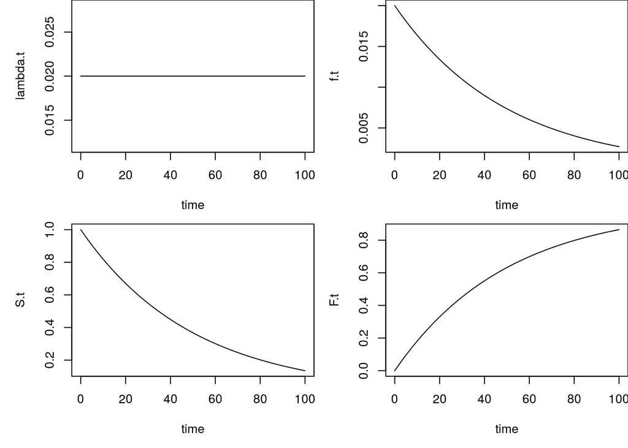

```r
time = 0:100
mu = 50 # mean time to death in weeks
lambda.t = rep(1/mu, times=length(time)) # hazard, here constant
f.t = (exp(-time/mu))/mu # death density (number of deaths per week)
S.t = exp(-time/mu) # survival function
F.t = 1- S.t

par(mfrow=c(2,2), mai=c(0.8,0.8,0,0))
plot(time, lambda.t, type="l")
plot(time, f.t, type="l")
plot(time, S.t, type="l")
plot(time, F.t, type="l")
```

# 5 Fitting the exponential model using package `survival`

## 5.1 The `seedlings` data

The data come from Crawley (2007) The R book; all of the datasets used in the book can be found [here](http://www.bio.ic.ac.uk/research/mjcraw/therbook/data/). Specifically, I will use the `seedlings.txt` example, which Crawley also uses for his demonstrations.

```r
  seedlings <- read.table("http://www.petrkeil.com/wp-content/uploads/2016/01/seedlings.txt", header=TRUE)
```

The data have three colums:

`cohort` – month in which the seedlings were planted.

`death` – week at which the seedling died.

`gapsize` – size of canopy gap at which germination occurred.

```r
  summary(seedlings)
```

```
##        cohort       death           gapsize
##  October  :30   Min.   : 1.000   Min.   :0.0291
##  September:30   1st Qu.: 2.000   1st Qu.:0.3982
##                 Median : 4.000   Median :0.6955
##                 Mean   : 5.367   Mean   :0.6144
##                 3rd Qu.: 8.000   3rd Qu.:0.8693
##                 Max.   :21.000   Max.   :0.9878
```

```r
  attach(seedlings)
```

A common practice in survival analysis is to indicate if the observed times to death are censored. In the `seedlings` data there are no censored observations, which I will indicate by creating a `status` variable containing only 1s:

```r
  status <- 1*(death>0)
  status # there are no censored observations
```

```
##  [1] 1 1 1 1 1 1 1 1 1 1 1 1 1 1 1 1 1 1 1 1 1 1 1 1 1 1 1 1 1 1 1 1 1 1 1
## [36] 1 1 1 1 1 1 1 1 1 1 1 1 1 1 1 1 1 1 1 1 1 1 1 1 1
```

Note the use of the status variable in the `cancer` example below, where we use real censored data, and where the status vector contains 0s and 1s.

## 5.2 The model fitting

`survival` package is the generic tool to do survival analysis in R.

```r
  library(survival)
```

I will use function `survreg` to fit parametric survival model with the `~1` indicating that I am only fitting the intecept – there will be no predictors or groups in the model.

```r
  model.par <- survreg(Surv(death)~1, dist="exponential")
  model.par
```

```
## Call:
## survreg(formula = Surv(death) ~ 1, dist = "exponential")
##
## Coefficients:
## (Intercept)
##    1.680207
##
## Scale fixed at 1
##
## Loglik(model)= -160.8   Loglik(intercept only)= -160.8
## n= 60
```

To get the estimate of $\mu$ (mean time to death) we do a simple exponentiation:

```r
  mu = exp(model.par$coeff)
```

Here are some derived quantities such as survival and failure density:

```r
  time=0:25
  S.t = exp(-time/mu)
  f.t = exp(-time/mu)/mu
```

## 5.3 Plotting the data and the model

First, I calculate survivorship from the raw data:

```r
  deaths <- tapply(X=status, INDEX=death, FUN = sum)
  survs <- (sum(deaths)-cumsum(deaths))/sum(deaths)
  death.data <- data.frame(day=as.numeric(names(survs)),
                           survs=as.numeric(survs))
```

And here is everything plotted together. The red lines represent the fitted model, black stuff is the raw data.

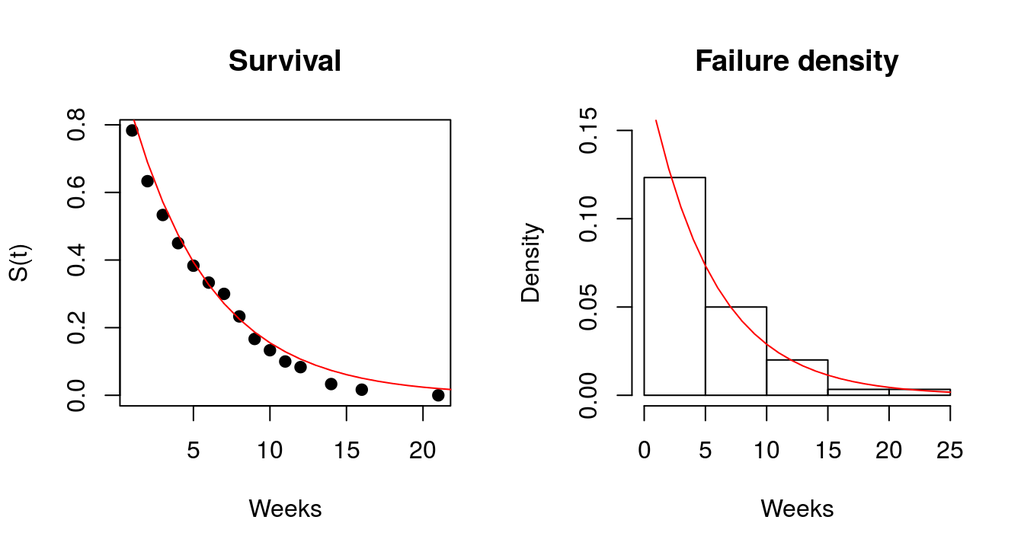

```r
  par(mfrow=c(1,2))
  plot(death.data, pch=19, ylab="S(t)", xlab="Weeks",
       main="Survival")
  lines(time, S.t, col="red")
  hist(seedlings$death, freq=FALSE, main="Failure density",
       xlab="Weeks", ylim=c(0,0.15))
  lines(time, f.t, col="red")
```

# 6 Fitting the exponential model in JAGS

Here I fit exactly the same model to the same data as above, but now I use the MCMC sampler in JAGS.

Some data preparation:

```r
  library(runjags)
  library(coda)
  new.t <- seq(0,25, by=0.5) # this will be used for prediction

  # put the data into list for JAGS
  surv.data = list(t.to.death = seedlings$death,
                   N = nrow(seedlings),
                   new.t = new.t,
                   new.N = length(new.t))
```

Model definition in the JAGS language:

```r
  cat("
    model
    {
      # prior
      lambda ~ dgamma(0.01, 0.01)

      # likelihood
      for(t in 1:N)
      {
        t.to.death[t] ~ dexp(lambda)
      }
      # mean time to death
      mu <- 1/lambda

      # predictions
      for(i in 1:new.N)
      {
        S.t[i] <- exp(-new.t[i]/mu)
      }
    }
    ", file="survival_exp.txt")
```

## 6.1 Estimating $\mu$ (mean time to death)

I first run the model and only monitor the $\mu$ node:

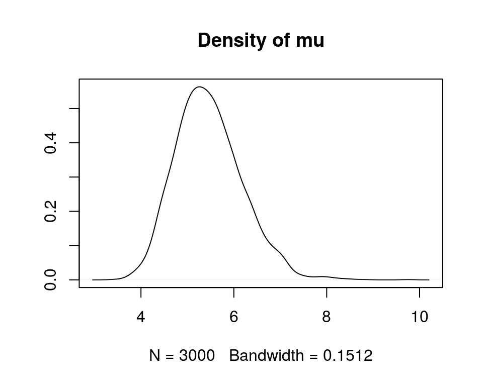

```r
  mu <- run.jags(data = surv.data,
                     model = "survival_exp.txt",
                     monitor = c("mu"),
                     sample = 1000, burnin = 1000, n.chains = 3)
  densplot(as.mcmc(mu), show.obs=FALSE)
```

This is the posterior density of mean time to death $\mu$. Now let’s get some predictions out.

## 6.2 Predictions and 95% prediction interval of $S(t)$

The model is really simple and data are tiny, and so I can afford to run the MCMC again for the predictions:

```r
  S.t <- run.jags(data = surv.data,
                     model = "survival_exp.txt",
                     monitor = c("S.t"),
                     sample = 2000, burnin = 1000, n.chains = 3)
  S.t <- summary(S.t)
```

And here are the raw data (black dots) and the fitted model (red).

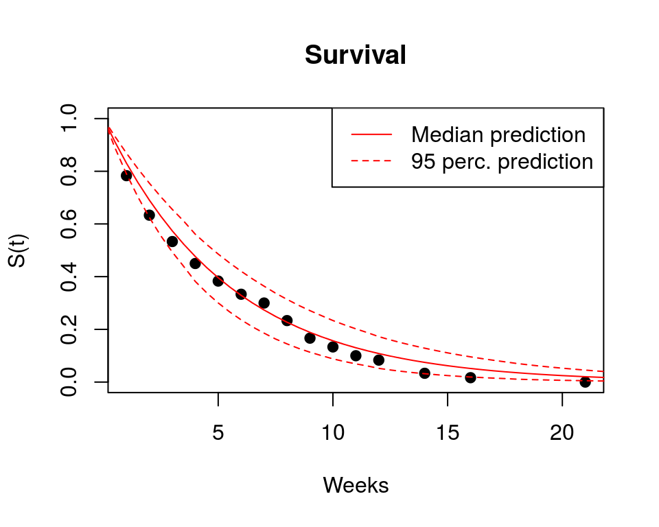

```r
  plot(death.data, pch=19, xlab="Weeks", ylab="S(t)",
       main="Survival", ylim=c(0,1))
  lines(new.t, S.t[,'Lower95'], lty=2, col="red")
  lines(new.t, S.t[,'Median'], col="red")
  lines(new.t, S.t[,'Upper95'], lty=2, col="red")
  legend("topright", legend=c("Median prediction","95 perc. prediction"),
         lty=c(1,2), col=c("red", "red"))
```

# 7 Censored exponential model in JAGS

**Censoring** occurs when we don’t know the time of death (failure) for all of the individuals; this can happen, for instance, when some patients outlive an experiment, while others leave the experiment before they die (Crawley 2007).

Here I use JAGS to fit a model with **right-censored** data.

## 7.1 The `cancer` data

The data for this example come, again, from Crawley’s book:

```r
  cancer <- read.table("http://www.petrkeil.com/wp-content/uploads/2016/01/cancer.txt", header=TRUE)
  summary(cancer)
```

```
##      death         treatment      status
##  Min.   : 1.00   DrugA  :30   Min.   :0.0
##  1st Qu.: 3.00   DrugB  :30   1st Qu.:1.0
##  Median : 6.00   DrugC  :30   Median :1.0
##  Mean   : 7.55   placebo:30   Mean   :0.8
##  3rd Qu.:10.00                3rd Qu.:1.0
##  Max.   :48.00                Max.   :1.0
```

The `status` variable indicates if the observation is censored (0) or if it represents real time to death (1).

## 7.2 Challenges of censoring in JAGS

Censoring in JAGS is done with `dinterval` distribution, and it takes some time to get the idea how it works. I recommend to study the censoring section in [JAGS user manual](http://ftp.iinet.net.au/pub/FreeBSD/distfiles/mcmc-jags/jags_user_manual.pdf), as well as this [Martyn Plummer’s presentation](http://www.math.helsinki.fi/openbugs/IceBUGS/Presentations/PlummerIceBUGS.pdf), slide 14.

Some **hard-earned insights**:

- Following the [OpenBugs’ Mice example](http://www.openbugs.net/Examples/Mice.html), individuals who are censored should be given a missing value in the vector of failure times `t.to.death` (see the code below), whilst individuals who fail are given a zero in the censoring time vector `t.cen`.
- Also, citing [this post](http://doingbayesiandataanalysis.blogspot.cz/2012/01/complete-example-of-right-censoring-in.html), censored data must be recorded as NA, not as the value of censoring limit!
- When explicitly initializing the chains, the censored values of the data must be explicitly initialized (to values above the censoring limits)! However, this was not an issue for me.

Here is how I prepare the data for JAGS, having in mind the points above:

```r
  censored <- cancer$status==0
  is.censored <- censored*1
  t.to.death <- cancer$death
  t.to.death[censored] <- NA
  t.to.death
```

```
##   [1]  4 26  2 25  7 NA  5 NA  4  1 10 48  4  3 17  2 NA 13  7 NA  8  5  2
##  [24]  2  4 NA 22  1  9  6 NA  8 11 NA  1  6  4  4  7 12 16 NA 19 NA 19 10
##  [47]  3 10 11 16  1  6  1 12  1  4 NA  2 14 11  1  4 16  3 12 NA  1 16  5
##  [70]  8  1  7 NA NA 12 19  3 NA  8  4 15  4  4  5  4  2 NA  9  3  4  1 NA
##  [93]  1  8 NA  4 NA  1 NA  9  4 NA  3  9  5  4  4 NA 13  4 NA  2  2  9 NA
## [116]  9 NA  4  5  9
```

```r
  t.cen <- rep(0, times=length(censored))
  t.cen[censored] <- cancer$death[censored]
  t.cen
```

```
##   [1]  0  0  0  0  0  6  0  2  0  0  0  0  0  0  0  0  8  0  0 10  0  0  0
##  [24]  0  0 26  0  0  0  0 10  0  0 11  0  0  0  0  0  0  0  8  0  3  0  0
##  [47]  0  0  0  0  0  0  0  0  0  0 14  0  0  0  0  0  0  0  0  4  0  0  0
##  [70]  0  0  0  2  1  0  0  0  4  0  0  0  0  0  0  0  0  7  0  0  0  0  6
##  [93]  0  0  3  0 10  0  7  0  0 12  0  0  0  0  0  7  0  0  7  0  0  0  6
## [116]  0  6  0  0  0
```

```r
  # put the data together for JAGS
  cancer.data <- list(t.to.death = t.to.death,
                      t.cen = t.cen,
                      N = nrow(cancer),
                      group = rep(1:4, each=30))
```

## 7.3 The model

The model assumes that survival in each of the four groups (indexed by $i$) is modelled by a stand-alone exponential model with its own $\lambda_i$.

Here is the model definition in JAGS, with the censoring modelled by the `dinterval` function:

```r
  cat("
    model
    {
      # priors
      for(j in 1:4)
      {
        # prior lambda for each group
        lambda[j] ~ dgamma(0.001, 0.001)
        mu[j] <- 1/lambda[j] # mean time to death
      }
      # likelihood
      for(i in 1:N)
      {
        is.censored[i] ~ dinterval(t.to.death[i], t.cen[i])
        t.to.death[i] ~ dexp(lambda[group[i]])
      }
   }
   ", file="survival_cancer.txt")
```

Running the model and monitoring the $\mu$ node:

```r
  library(runjags)
  library(coda)

  cancer.fit <- run.jags(data = cancer.data,
                         model = "survival_cancer.txt",
                         monitor = c("mu"),
                         sample = 1000, burnin = 1000, n.chains = 3)
```

And here are the posterior densities for each group’s mean time to death $\mu$:

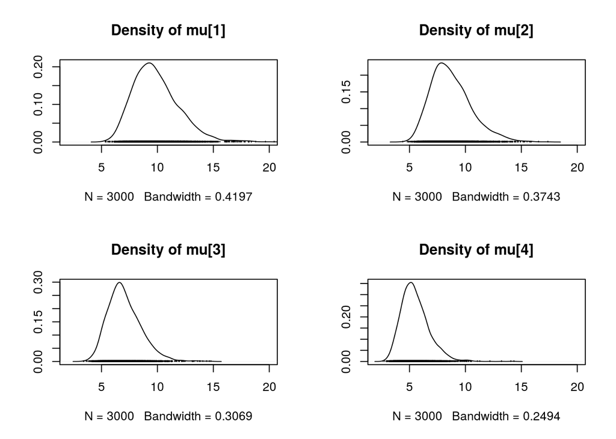

```r
  par(mfrow=c(2,2))
  densplot(as.mcmc(cancer.fit), xlim=c(2,20))
```

`mu[1:3]` are for the treatments, `mu[4]` is the placebo.